# Reproducible Research: Peer Assessment 1

Todd B

01/17/2015

## Load and preprocess the data

Load the data (i.e. read.csv() )

```r
data_orig <- read.csv("~/classes/ReproData/RepData_PeerAssessment1/activity.csv")
```

Process/transform the data (if necessary) into a format suitable for analysis. For this part of the assignment, the missing values in the dataset are ignored.

```r
data_nna <- subset(data_orig, !is.na(data_orig$steps))
```

## Histogram of the total number of steps taken each day

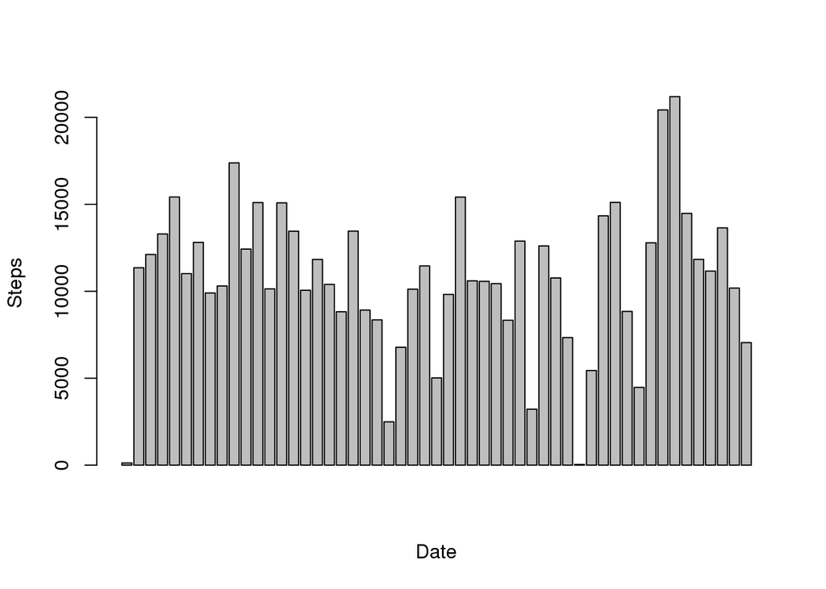

```r
data_nna_by_date <- aggregate(data_nna$steps, by=list(data_nna$date), FUN=sum)
names(data_nna_by_date) <- c("interv", "sum")

barplot(data_nna_by_date$sum, ylab = "Steps", xlab="Date")
```

## Average daily activity pattern:

Mean total number of steps taken per day:

```r
mean(data_nna_by_date$sum)
```

```
## [1] 10766.19
```

Median total number of steps taken per day:

```r
median(data_nna_by_date$sum)
```

```
## [1] 10765
```

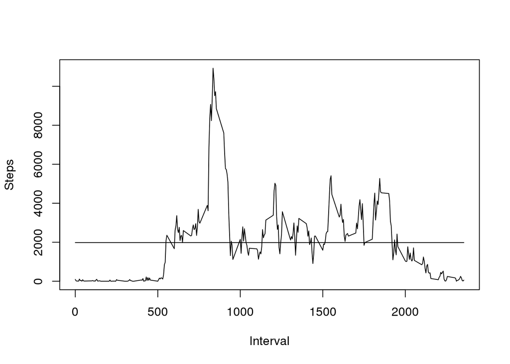

```r
data_nna_by_interv <- aggregate(data_nna$steps, by=list(data_nna$interval), FUN=sum)
num_days <- length(unique(data_nna$date))
data_nna_by_interv <- cbind(data_nna_by_interv, data_nna_by_interv[,2]/num_days)
names(data_nna_by_interv) <- c("interv", "sum", "day_av")

num_interv <- dim(data_nna_by_interv)[1]
interv_av <- sum(data_nna_by_interv$sum)/num_interv

plot.ts(data_nna_by_interv[,1], data_nna_by_interv[,2], ylab = "Steps", xlab="Interval", type = "l")
lines(data_nna_by_interv$interv, cbind(data_nna_by_interv, interv_av)[,4])
```

## Which 5-minute interval, on average across all the days in the dataset, contains the maximum number of steps?

The maximum number of steps is:

```r
max_val <- max(data_nna_by_interv[,2])
max_val
```

```
## [1] 10927
```

Which is found at interval number:

```r
max_int <- data_nna_by_interv[which(data_nna_by_interv[,2]== max_val),1]
max_int
```

```
## [1] 835
```

Which is at index number:

```r
which(data_nna_by_interv[,1]== max_int)
```

```
## [1] 104
```

## Impute missing values

Create a new dataset that is equal to the original dataset but with the missing data filled in. Missing data is filled in with the mean step value for that interval:

```r
data_imp <- data_orig
for (i in 1:dim(data_orig)[1]) {
    if (is.na(data_orig[i,1])) {
        step_ndx <- which(data_nna_by_interv$interv == data_orig$interv[i])
        data_imp$steps[i] <- data_nna_by_interv$day_av[step_ndx]
        #print(c(step_ndx, data_nna_by_interv$day_av[step_ndx]))
    }
}
```

Total number of missing values in the dataset (i.e. the total number of rows with NAs):

```r
dim(data_orig)[1] - dim(data_nna)[1]
```

```
## [1] 2304
```

## Histogram of the total number of steps taken each day.

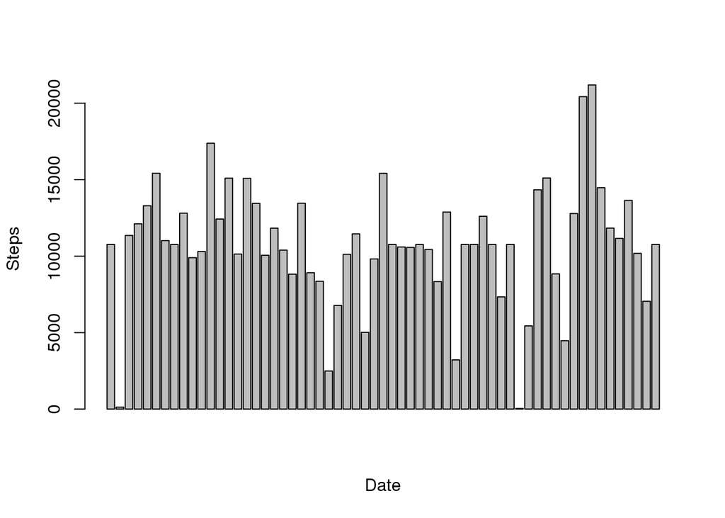

```r
data_imp_by_date <- aggregate(data_imp$steps, by=list(data_imp$date), FUN=sum)

data_imp_by_interv <- aggregate(data_imp$steps, by=list(data_imp$interval), FUN=sum)

barplot(data_imp_by_date[,2], ylab = "Steps", xlab="Date")
```

Mean and median total number of steps taken per day:

```r
mean(data_imp_by_date[,2])
```

```
## [1] 10766.19
```

```r
median(data_imp_by_date[,2])
```

```
## [1] 10766.19
```

## Differences in activity patterns between weekdays and weekends:

Create a new factor variable in the dataset with two levels – “weekday” and “weekend” indicating whether a given date is a weekday or weekend day.

```r
data_imp <- cbind(data_imp, as.factor((weekdays(strptime(data_imp[,2], format = "%Y-%m-%d")) == "Saturday" | weekdays(strptime(data_imp[,2], format = "%Y-%m-%d")) == "Sunday" )))
colnames(data_imp) <- c("steps", "date", "interval", "weekend")
```

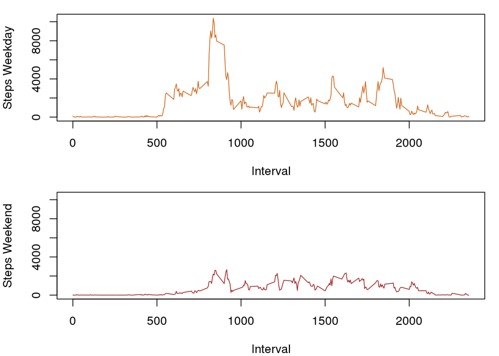

```r
data_tmp <- subset(data_imp, data_imp$weekend == FALSE)
data_imp_by_interv <- cbind(data_imp_by_interv, aggregate(data_tmp$steps, by=list(data_tmp$interval), FUN=sum)[2])

data_tmp <- subset(data_imp, data_imp$weekend == TRUE)
data_imp_by_interv <- cbind(data_imp_by_interv, aggregate(data_tmp$steps, by=list(data_tmp$interval), FUN=sum)[2])

names(data_imp_by_interv) <- c("interval", "steps", "wkday", "wkend")
max_steps <- max(c(max(data_imp_by_interv[,3]), max(data_imp_by_interv[,4])))

par(mfrow=c(2,1), mar=c(4,4,1,1) )
plot(data_imp_by_interv$interval, data_imp_by_interv$wkday, type="l", col="chocolate",
xlab="Interval", ylab="Steps Weekday", ylim=c(0, max_steps) )
plot(data_imp_by_interv$interval, data_imp_by_interv$wkend, type="l", col = "brown", xlab="Interval", ylab="Steps Weekend", ylim=c(0, max_steps) )
```

Horizontal panel plot of the same data which shows more clearly the differences in step activity:

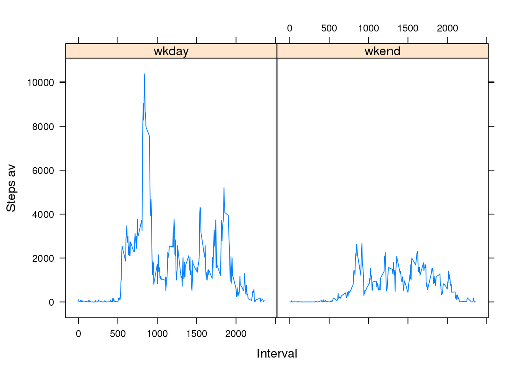

```r
data_plot <- data_imp_by_interv[,c(1,3)]
data_plot <- cbind(data_plot, "wkday")
names(data_plot) <- c("interval", "steps", "day")

data_tmp <- data_imp_by_interv[,c(1,4)]
data_tmp <- cbind(data_tmp, "wkend")
names(data_tmp) <- c("interval", "steps", "day")

data_plot <- rbind(data_plot, data_tmp)
max_steps <- max(data_plot[,2])

library(lattice)
xy_plot <- xyplot(steps ~ interval | day, data=data_plot, outer=T, type='l',
xlab=c('Interval'), ylab=c('Steps av'),
panel=function(x, y,...){
    panel.xyplot(x,y, type='l',
    ylim=max_steps)
})
print(xy_plot)
```